# Search: Solving a Maze Using a Goal-based Agent

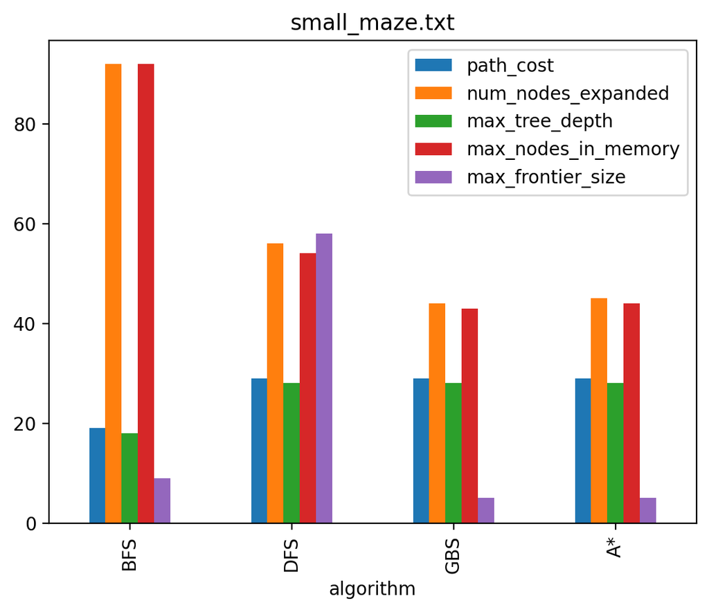

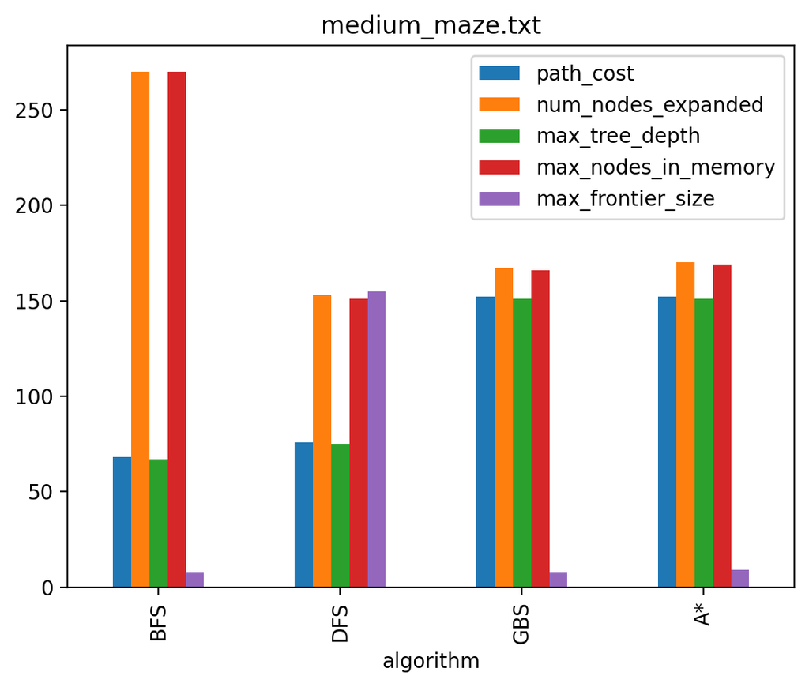

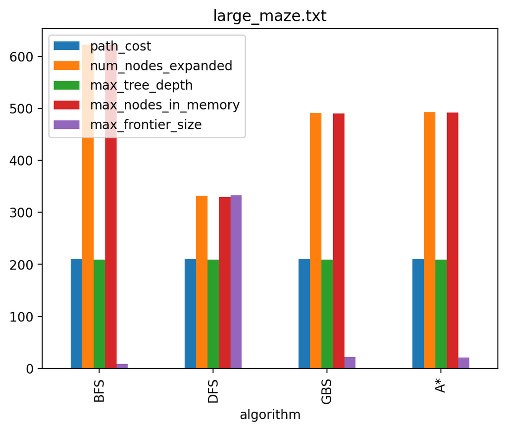

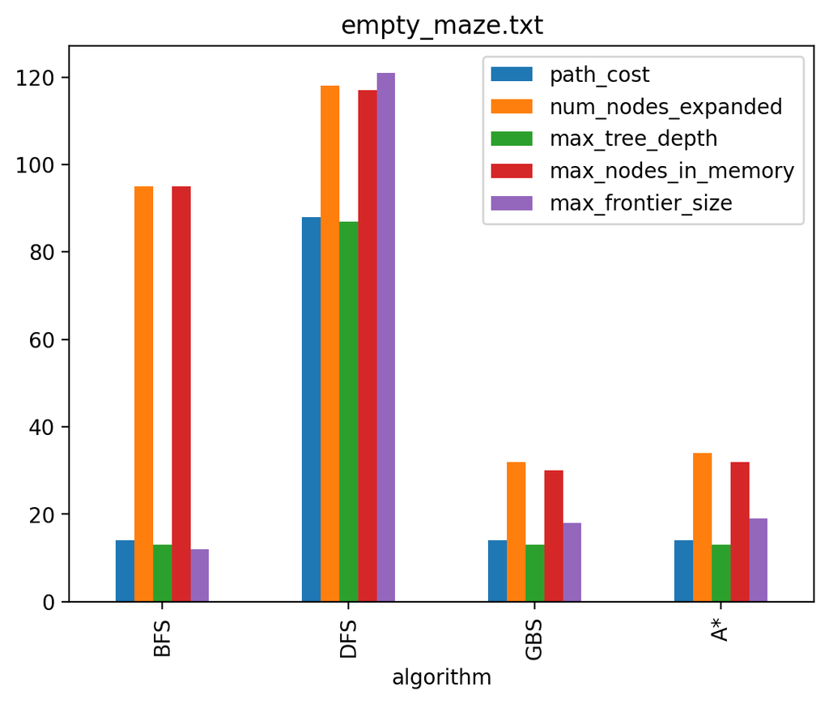

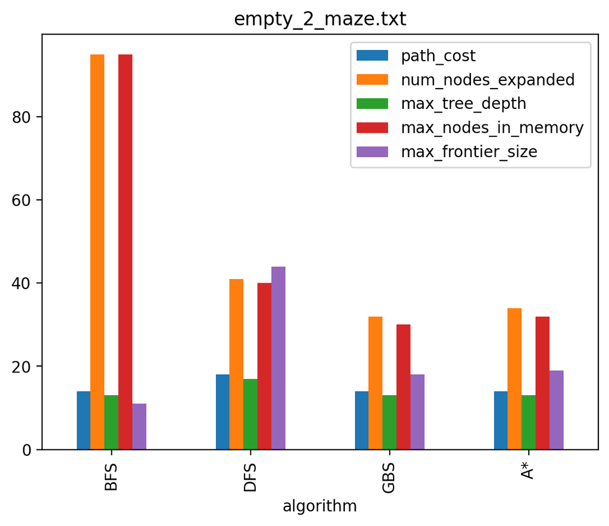

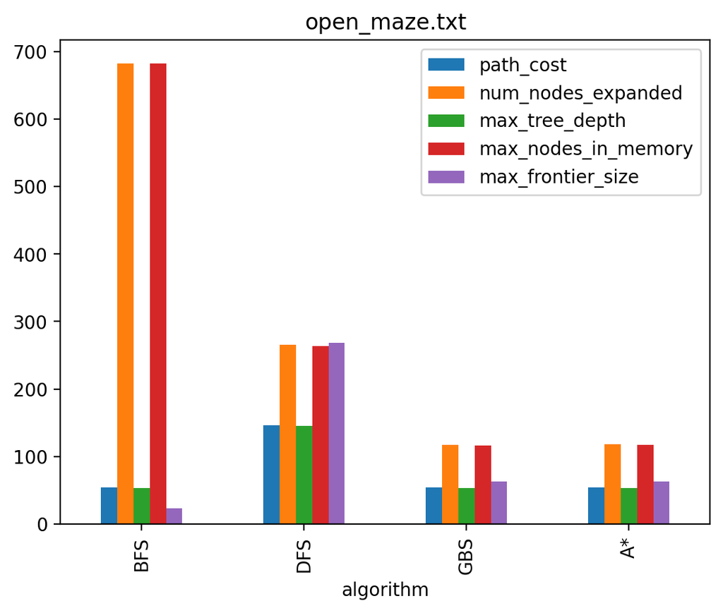

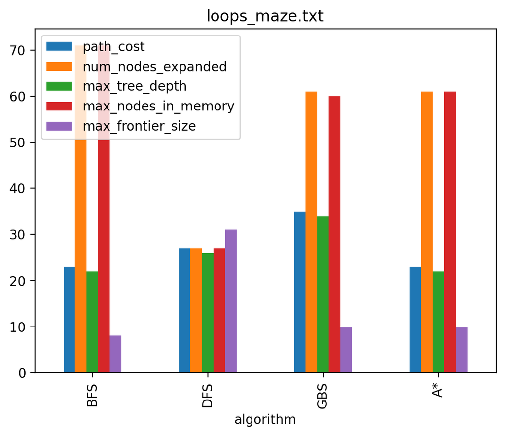

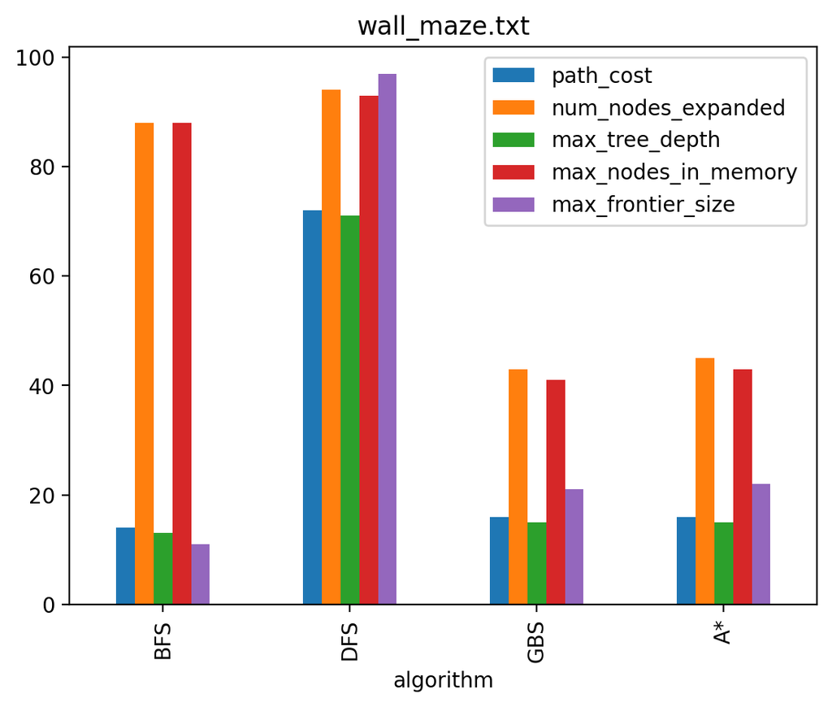

```python
# Add charts
import matplotlib.pyplot as plt

columns = ['algorithm', 'path_cost', 'num_nodes_expanded', 'max_tree_depth', 'max_nodes_in_memory', 'max_frontier_size']

for item in table_dict:
    # creates local dataframe
    df = table_dict[item]

    # creates bar chart for dataframe
    df.plot.bar(x = "algorithm", y = columns[1:], title = item)
    plt.show()
```

Discuss the most important lessons you have learned from implementing the different search strategies.

### Add discussion

##### The primary thing that I have learned through implementing all these search algorithms, is that there is not necessarily always one best algorithm for every case, each algorithm has its own strengths and weaknesses and can be the best option dpending on the task at hand. Furthermore, I learned that although an algorithms may seem to work for every situation, there are always exceptions that you will have to adjust for as you try more scenarios. For example, as seen through the graphs, Depth First Search seems to consistently be less computationally expensive then Breadth First Search. However, on the wall_maze and empty_maze in particular, DFS performs significantly just due to the nature of how the maze is layed out and which directions DFS prioritizes.

## Graduate student advanced task: IDS and Multiple goals [10 Points]

**Undergraduate students:** This is a bonus task you can attempt if you like [+5 Bonus Points].

Create a few mazes with multiple goals by adding one or two more goals to the medium size maze. Solve the maze with your implementations for DFS, BFS, and implement in addition IDS (iterative deepening search using DFS).

Run experiments to show which implementations find the optimal solution and which do not. Discuss why that is the case.

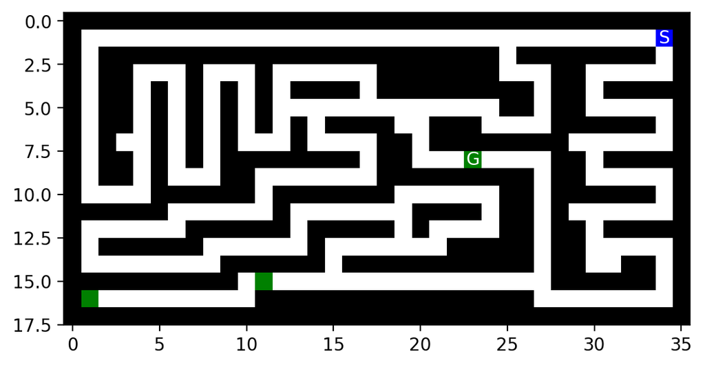

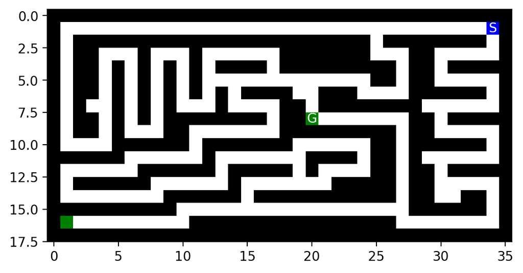

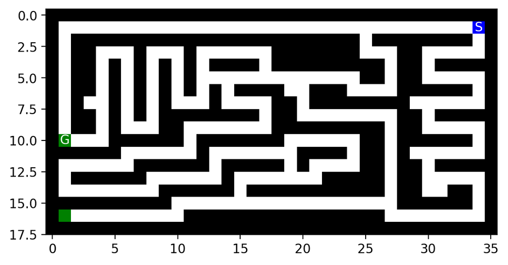

```python
# Your code/answer goes here

import random

# medium maze
with open("medium_maze.txt", "r") as f:
    maze_str = f.read()
    maze_medium = mh.parse_maze(maze_str)

# initialize 3 mazes with multiple goals
multiple_goals_mazes = []
multiple_goals_mazes.append(copy.deepcopy(maze_medium))
multiple_goals_mazes.append(copy.deepcopy(maze_medium))
multiple_goals_mazes.append(copy.deepcopy(maze_medium))

# randomly assigns new goal states to the mazes
x = 0
while x < 3:

    # assigns goals states
    for i in range(len(multiple_goals_mazes[x])):
        for j in range(len(multiple_goals_mazes[x][i])):
            rand_num = random.randint(0, 500)
            if rand_num < 2 and multiple_goals_mazes[x][i][j] != "S" and multiple_goals_mazes[x][i][j] != "X":
                multiple_goals_mazes[x][i][j] = "G"

    # checks to see if enough goals were added, it not then it reruns the loop
    goal_counter = 0
    for i in range(len(multiple_goals_mazes[x])):
        for j in range(len(multiple_goals_mazes[x][i])):
            if multiple_goals_mazes[x][i][j] == "G":
                goal_counter += 1

    if goal_counter < 2:
        multiple_goals_mazes[x] = copy.deepcopy(maze_medium)
        x -= 1
    x += 1

for new_maze in multiple_goals_mazes:
    mh.show_maze(new_maze)


def IDS(maze, limit = 1000000, hueristic = None):
    for i in range(limit):
        Path_End, reached, path_cost, num_nodes_expanded, max_tree_depth, max_nodes_in_memory, max_frontier_size = DFS(maze, i, None)
        result = Path_End, reached, path_cost, num_nodes_expanded, max_tree_depth, max_nodes_in_memory, max_frontier_size
        if result != "cutoff":
            return result
```

```
Node - pos = (8, 1); action = WEST; cost = 29
```

```
path_cost: 29 num_nodes_expanded: 56 max_tree_depth: 28 max_nodes_in_memory: 54 max_frontier_size: 58

Node - pos = (16, 1); action = WEST; cost = 76
```

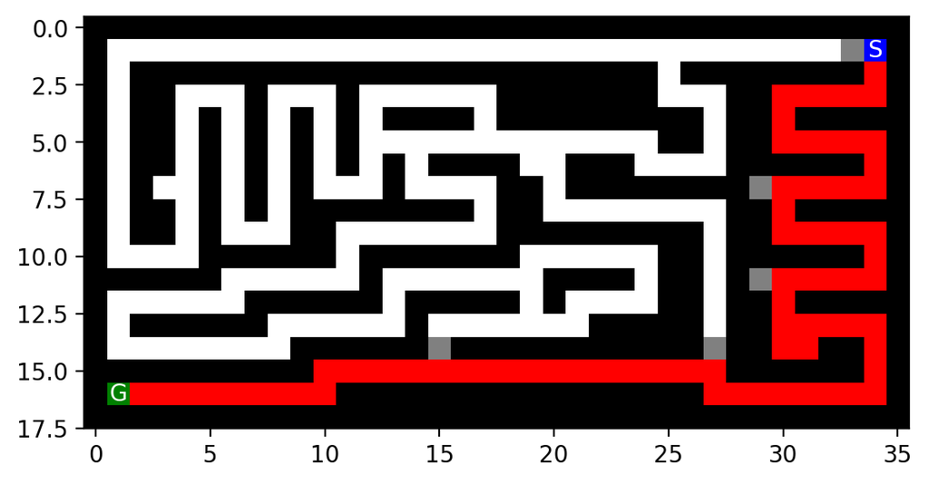

```
path_cost: 76 num_nodes_expanded: 153 max_tree_depth: 75 max_nodes_in_memory: 151 max_frontier_size: 155

Node - pos = (35, 1); action = SOUTH; cost = 210
```

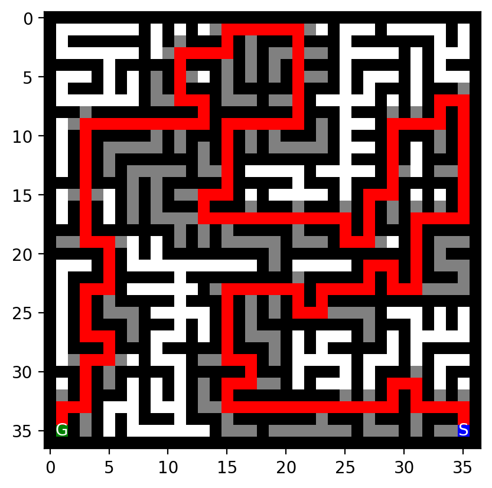

```
path_cost: 210 num_nodes_expanded: 332 max_tree_depth: 209 max_nodes_in_memory: 329 max_frontier_size: 333

Path_End: Node - pos = (2, 9); action = EAST; cost = 88
```

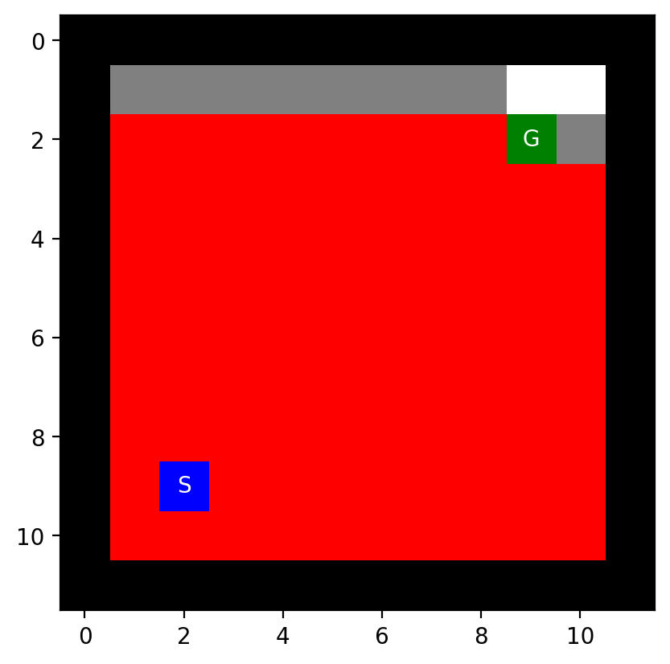

```
path_cost: 88 num_nodes_expanded: 118 max_tree_depth: 87 max_nodes_in_memory: 117 max_frontier_size: 121

Path_End: Node - pos = (9, 2); action = EAST; cost = 18
```

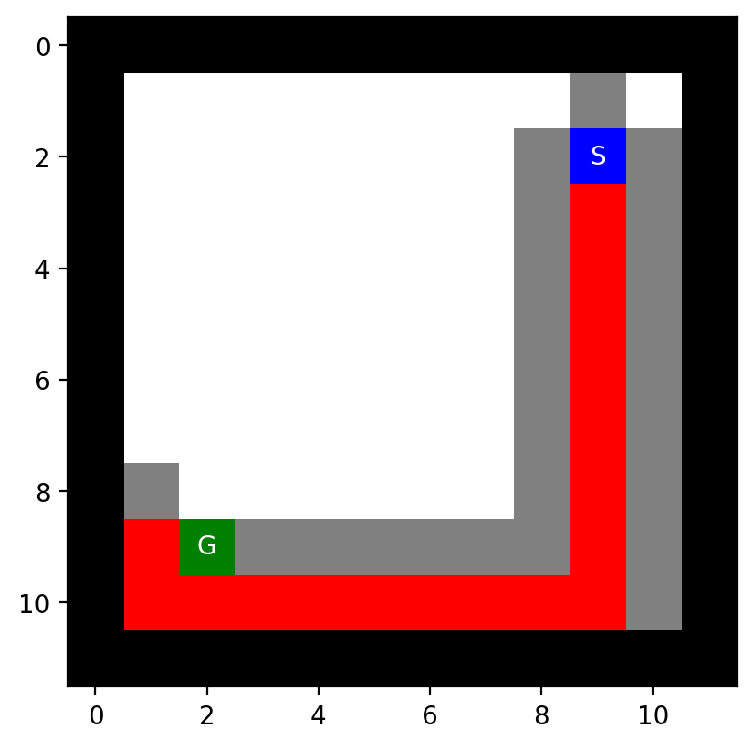

```
path_cost: 18 num_nodes_expanded: 41 max_tree_depth: 17 max_nodes_in_memory: 40 max_frontier_size: 44

Path_End: Node - pos = (21, 1); action = WEST; cost = 146
```

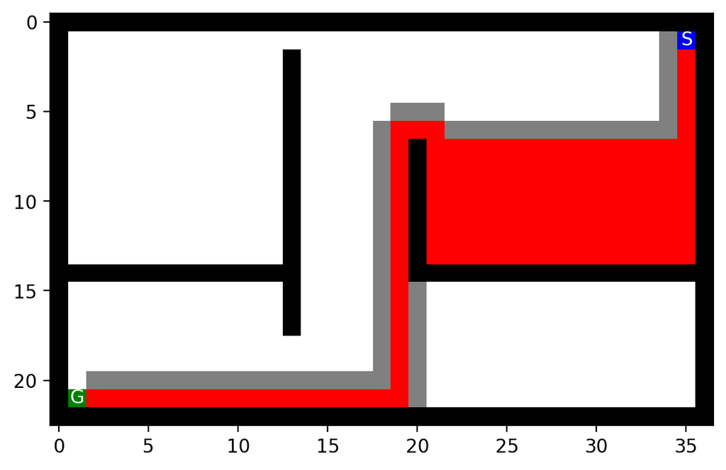

```
path_cost: 146 num_nodes_expanded: 266 max_tree_depth: 145 max_nodes_in_memory: 264 max_frontier_size: 268

Path_End: Node - pos = (1, 1); action = NORTH; cost = 27
```

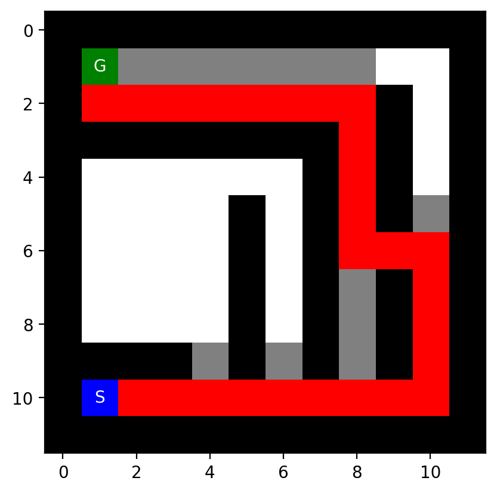

```
path_cost: 27 num_nodes_expanded: 27 max_tree_depth: 26 max_nodes_in_memory: 27 max_frontier_size: 31

Path_End: Node - pos = (2, 9); action = EAST; cost = 72
```

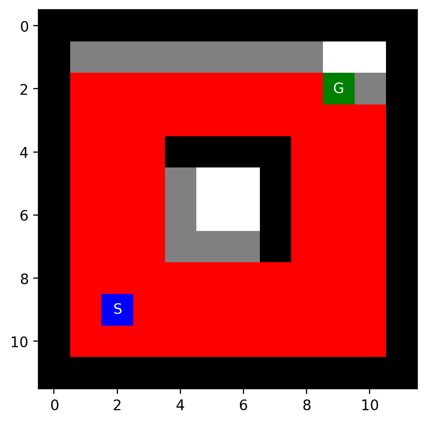

```
path_cost: 72 num_nodes_expanded: 94 max_tree_depth: 71 max_nodes_in_memory: 93 max_frontier_size: 97
```

```python
# tests IDS on all mazes
test_mazes(IDS, 100, None)
```

```python
import pandas as pd

all_tables = []

for maze in multiple_goals_mazes:
    my_maze = copy.deepcopy(maze)

    df = pd.DataFrame(columns = ["algorithm", "path_cost", "num_nodes_expanded", "max_tree_depth", "max_nodes_in_memory", "max_frontier_size"])

    Path_End, reached, path_cost, num_nodes_expanded, max_tree_depth, max_nodes_in_memory, max_frontier_size = BFS(my_maze)
    df.loc[len(df.index)] = ["BFS", path_cost, num_nodes_expanded,  max_tree_depth, max_nodes_in_memory, max_frontier_size]
    Path_End, reached, path_cost, num_nodes_expanded, max_tree_depth, max_nodes_in_memory, max_frontier_size = DFS(my_maze, 10000000)
    df.loc[len(df.index)] = ["DFS", path_cost, num_nodes_expanded,  max_tree_depth, max_nodes_in_memory, max_frontier_size]
    Path_End, reached, path_cost, num_nodes_expanded, max_tree_depth, max_nodes_in_memory, max_frontier_size = IDS(my_maze, 10000000)
    df.loc[len(df.index)] = ["IDS", path_cost, num_nodes_expanded, max_tree_depth, max_nodes_in_memory, max_frontier_size]

    all_tables.append(df)

for table in all_tables:
    display(table)
```

|  | algorithm | path_cost | num_nodes_expanded | max_tree_depth | max_nodes_in_memory | max_frontier_size |
| --- | --- | --- | --- | --- | --- | --- |
| 0 | BFS | 68 | 270 | 67 | 270 | 8 |
| 1 | DFS | 76 | 153 | 75 | 151 | 155 |
| 2 | IDS | 76 | 153 | 75 | 151 | 155 |

|  | algorithm | path_cost | num_nodes_expanded | max_tree_depth | max_nodes_in_memory | max_frontier_size |
| --- | --- | --- | --- | --- | --- | --- |
| 0 | BFS | 68 | 270 | 67 | 270 | 8 |
| 1 | DFS | 76 | 153 | 75 | 151 | 155 |
| 2 | IDS | 76 | 153 | 75 | 151 | 155 |

|  | algorithm | path_cost | num_nodes_expanded | max_tree_depth | max_nodes_in_memory | max_frontier_size |
| --- | --- | --- | --- | --- | --- | --- |
| 0 | BFS | 68 | 270 | 67 | 270 | 8 |
| 1 | DFS | 76 | 153 | 75 | 151 | 155 |
| 2 | IDS | 76 | 153 | 75 | 151 | 155 |

## More advanced tasks to think about

Instead of defining each square as a state, use only intersections as states. Now the storage requirement is reduced, but the path length between two intersections can be different. If we use total path length measured as the number of squares as path cost, how can we make sure that BFS and iterative deepening search is optimal? Change the code to do so.

```python
# Your code/answer goes here
```

Modify your A* search to add weights (see text book) and explore how different weights influence the result.

```python
# Your code/answer goes here
```

What happens if the agent does not know the layout of the maze in advance (i.e., faces an unkown, only partially observable environment)? How does the environment look then (PEAS description)? How would you implement a rational agent to solve the maze? What if the agent still has a GPS device to tell the distance to the goal?

```python
# Your code/answer goes here
```